# Section 5: DATA/STAT 234 Review

Author

Bryana A. S. Thieret

*——————————————————————————-*

## 5.1: Review with HPI Data (Class Prep)

### 5.1.1: Making a Scatterplot and Labeling Points

- In making visualizations, we sometimes want to either highlight, by using a unique color, size, or shape, a specific observation or we might want to label a specific observation.

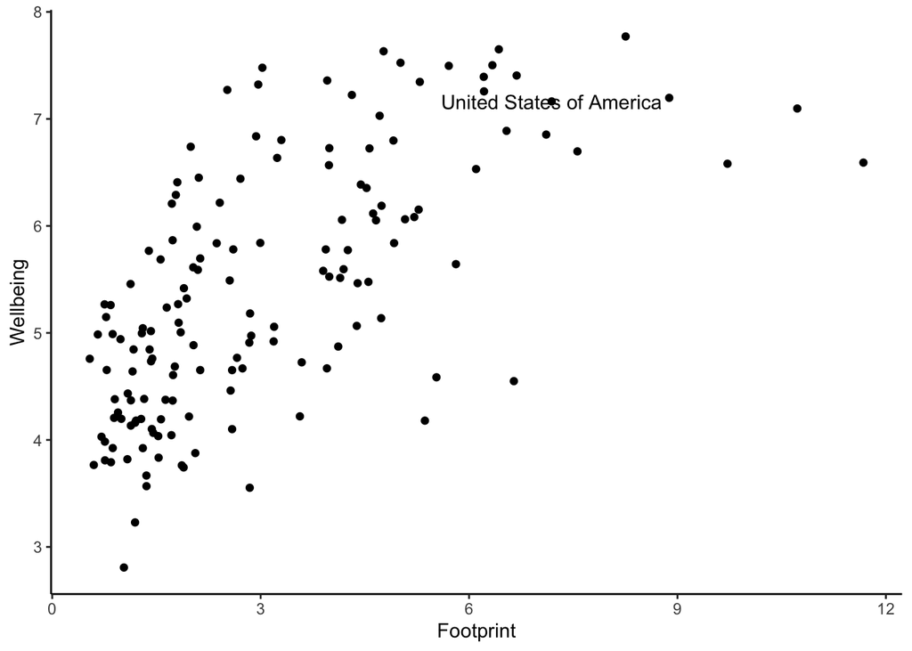

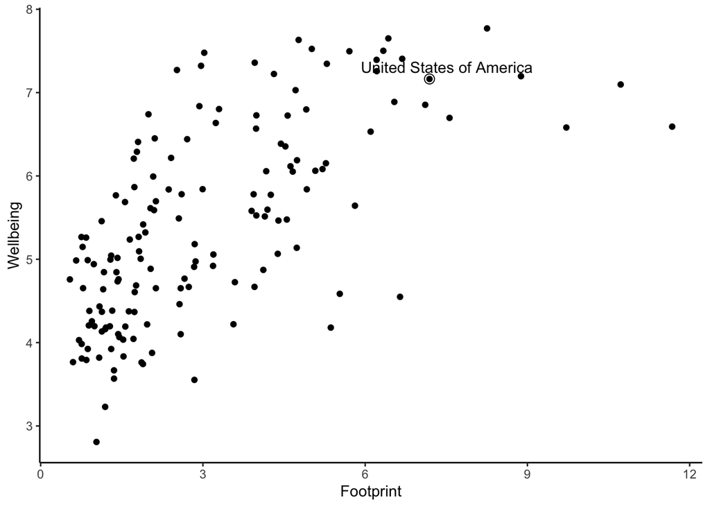

### 5.1.2: Themes and Labels

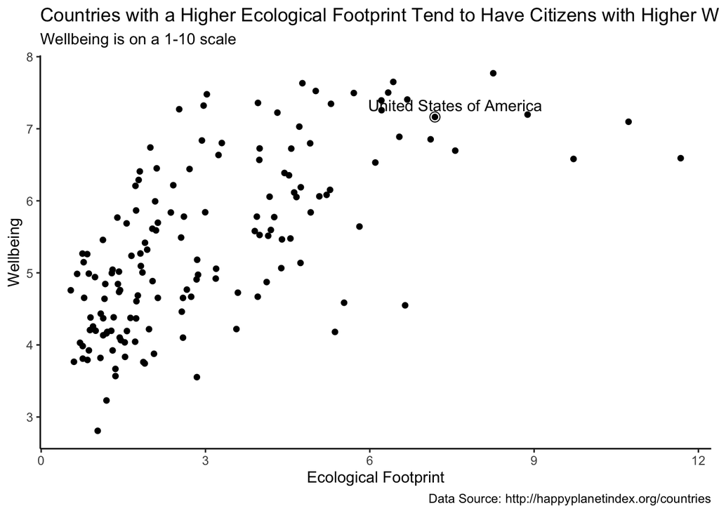

*——————————————————————————-*

**Exercise 1**: For each of the core dplyr functions mutate(), arrange(), select(), slice(), filter(), group_by(), and summarise(), write a one sentence summary of the overall purpose of the function.  
* `mutate()` : adds a new completely new column to the far right and does not alter any of the current columns or rows (unless you name the column the same thing as an already existing column)  
* `arrange()` : puts a numeric variable in order in assending order.  
* `select()` : column removal for an existing dataset or including columns to a new dataset based off of an already existing dataset.  
* `slice()` : removal or rows by number/value or subset of numbers/values.  
* `filter()` : uses a conditional statement, or statements, to remove a certain variable from the dataset by row.  
* `group_by()` : often used with summarise() to get sample statistics by subcategories within a particular categorical variables levels.  
* `summmarise()` : sample statistics from data.

**Exercise 2:** Review mutate(). Create a new variable in hpi_df that is equal to Wellbeing / Footprint.

```
# A tibble: 151 × 12
   HPIRank Country     LifeExpectancy Wellbeing HappyLifeYears Footprint
     <dbl> <chr>                <dbl>     <dbl>          <dbl>     <dbl>
 1     109 Afghanistan           48.7      4.76           29.0     0.540
 2      18 Albania               76.9      5.27           48.8     1.81
 3      26 Algeria               73.1      5.24           46.2     1.65
 4     127 Angola                51.1      4.21           28.2     0.891
 5      17 Argentina             75.9      6.44           55.0     2.71
 6      53 Armenia               74.2      4.37           41.9     1.73
 7      76 Australia             81.9      7.41           65.5     6.68
 8      48 Austria               80.9      7.35           64.3     5.29
 9      80 Azerbaijan            70.7      4.22           39.1     1.97
10     146 Bahrain               75.1      4.55           43.5     6.65
# ℹ 141 more rows
# ℹ 6 more variables: HappyPlanetIndex <dbl>, Population <dbl>,
#   GDPcapita <dbl>, GovernanceRank <chr>, Region <chr>,
#   `welbeing/footprint` <dbl>
```

**Exercise 3:** Review mutate() and case_when(). Create a new variable in hpi_df that is equal to “80s” if LifeExp is in the 80’s, “70s” if LifeExp is in the 70s, and “Below 70” if LifeExp is less than 70.

```
# A tibble: 151 × 12
   HPIRank Country     LifeExpectancy Wellbeing HappyLifeYears Footprint
     <dbl> <chr>                <dbl>     <dbl>          <dbl>     <dbl>
 1     109 Afghanistan           48.7      4.76           29.0     0.540
 2      18 Albania               76.9      5.27           48.8     1.81
 3      26 Algeria               73.1      5.24           46.2     1.65
 4     127 Angola                51.1      4.21           28.2     0.891
 5      17 Argentina             75.9      6.44           55.0     2.71
 6      53 Armenia               74.2      4.37           41.9     1.73
 7      76 Australia             81.9      7.41           65.5     6.68
 8      48 Austria               80.9      7.35           64.3     5.29
 9      80 Azerbaijan            70.7      4.22           39.1     1.97
10     146 Bahrain               75.1      4.55           43.5     6.65
# ℹ 141 more rows
# ℹ 6 more variables: HappyPlanetIndex <dbl>, Population <dbl>,
#   GDPcapita <dbl>, GovernanceRank <chr>, Region <chr>, LifeExpCat <chr>
```

**Exercise 4:** Review arrange(). Sort the hpi_df data so that the country with the highest LifeExp is in the first row and the country with the lowest LifeExp is in the last row.

```
# A tibble: 151 × 11
   HPIRank Country     LifeExpectancy Wellbeing HappyLifeYears Footprint
     <dbl> <chr>                <dbl>     <dbl>          <dbl>     <dbl>
 1      45 Japan                 83.4      6.06           58.0      4.17
 2     102 Hong Kong             82.8      5.64           54.9      5.81
 3      34 Switzerland           82.3      7.52           66.5      5.01
 4      76 Australia             81.9      7.41           65.5      6.68
 5      51 Italy                 81.9      6.35           58.8      4.52
 6      88 Iceland               81.8      6.89           62.1      6.54
 7      15 Israel                81.6      7.36           64.9      3.96
 8      50 France                81.5      6.80           61.3      4.91
 9      62 Spain                 81.4      6.19           57.4      4.74
10      52 Sweden                81.4      7.50           65.6      5.71
# ℹ 141 more rows
# ℹ 5 more variables: HappyPlanetIndex <dbl>, Population <dbl>,
#   GDPcapita <dbl>, GovernanceRank <chr>, Region <chr>
```

**Exercise 5:** Review select(). Make a data frame from hpi_df that only has the variables Country and LifeExp.

```
# A tibble: 151 × 2
   Country     LifeExpectancy
   <chr>                <dbl>
 1 Afghanistan           48.7
 2 Albania               76.9
 3 Algeria               73.1
 4 Angola                51.1
 5 Argentina             75.9
 6 Armenia               74.2
 7 Australia             81.9
 8 Austria               80.9
 9 Azerbaijan            70.7
10 Bahrain               75.1
# ℹ 141 more rows
```

**Exercise 6:** Review slice(). Make a data frame from hpi_df that only has the first 5 rows.

```
# A tibble: 5 × 11
  HPIRank Country     LifeExpectancy Wellbeing HappyLifeYears Footprint
    <dbl> <chr>                <dbl>     <dbl>          <dbl>     <dbl>
1     109 Afghanistan           48.7      4.76           29.0     0.540
2      18 Albania               76.9      5.27           48.8     1.81
3      26 Algeria               73.1      5.24           46.2     1.65
4     127 Angola                51.1      4.21           28.2     0.891
5      17 Argentina             75.9      6.44           55.0     2.71
# ℹ 5 more variables: HappyPlanetIndex <dbl>, Population <dbl>,
#   GDPcapita <dbl>, GovernanceRank <chr>, Region <chr>
```

**Exercise 7:** Review filter(). Make a data frame from hpi_df that only has countries in the “Western World” Region.

[output not shown]

**Exercise 8:** Review filter(). Make a data frame from hpi_df that only has countries with a LifeExp less than 55.

```
# A tibble: 19 × 11
   HPIRank Country             LifeExpectancy Wellbeing HappyLifeYears Footprint
     <dbl> <chr>                        <dbl>     <dbl>          <dbl>     <dbl>
 1     109 Afghanistan                   48.7      4.76           29.0     0.540
 2     127 Angola                        51.1      4.21           28.2     0.891
 3     151 Botswana                      53.2      3.55           26.7     2.84
 4     135 Burundi                       50.4      3.79           26.2     0.845
 5     124 Cameroon                      51.6      4.43           29.4     1.09
 6     148 Central African Re…           48.4      3.57           24.3     1.36
 7     150 Chad                          49.6      3.74           25.6     1.89
 8     134 Congo, Dem. Rep. o…           48.4      3.98           25.9     0.758
 9     137 Guinea                        54.1      4.04           29.2     1.72
10      72 Malawi                        54.2      5.15           33.9     0.776
11     147 Mali                          51.4      3.76           26.6     1.86
12     114 Mozambique                    50.2      4.65           29.4     0.784
13     144 Niger                         54.7      4.10           29.8     2.59
14     125 Nigeria                       51.9      4.76           30.9     1.44
15     139 Sierra Leone                  47.8      4.13           26.1     1.13
16     142 South Africa                  52.8      4.65           31.0     2.59
17     131 Uganda                        54.1      4.19           29.8     1.57
18      99 Zambia                        49        5.26           31.0     0.841
19     115 Zimbabwe                      51.4      4.85           30.9     1.17
# ℹ 5 more variables: HappyPlanetIndex <dbl>, Population <dbl>,
#   GDPcapita <dbl>, GovernanceRank <chr>, Region <chr>
```

**Exercise 9:** Review group_by() and summarise(). Make a table of the number of countries in each Region. (Hint: recall that the n() function is the counting function in dplyr).

```
# A tibble: 7 × 2
  Region                           n
  <chr>                        <int>
1 East Asia                       12
2 Latin America                   24
3 Middle East and North Africa    20
4 South Asia                       6
5 Sub Saharan Africa              37
6 Transition States               28
7 Western World                   24
```

**Exercise 10** Review group_by() and summarise(). Make a table with the maximum LifeExp in each Region.

```
# A tibble: 7 × 2
  Region                         max
  <chr>                        <dbl>
1 East Asia                     83.4
2 Latin America                 79.3
3 Middle East and North Africa  81.6
4 South Asia                    74.9
5 Sub Saharan Africa            73.4
6 Transition States             79.3
7 Western World                 82.3
```

*——————————————————————————-*

## 5.2: More Review with Billboard Hot 100

*——————————————————————————-*

## 5.3: Your Turn